# Linear Regression

### Multiple Linear Regression

In order to fit a multiple linear regression model using least squares, we again use the sm.OLS() function. The syntax is similar, but X is now an $n$x$p$ matrix of the features. The summary() function now outputs the regression coefficients for all the predictors.

```python
model = smf.ols('MEDV ~ LSTAT + AGE', data=Boston)
res = model.fit()
print(res.summary())
```

```
                            OLS Regression Results
==============================================================================
Dep. Variable:                   MEDV   R-squared:                       0.551
Model:                            OLS   Adj. R-squared:                  0.549
Method:                 Least Squares   F-statistic:                     309.0
Date:                Mon, 25 May 2020   Prob (F-statistic):           2.98e-88
Time:                        10:44:19   Log-Likelihood:                -1637.5
No. Observations:                 506   AIC:                             3281.
Df Residuals:                     503   BIC:                             3294.
Df Model:                           2
Covariance Type:            nonrobust
==============================================================================
                 coef    std err          t      P>|t|      [0.025      0.975]
------------------------------------------------------------------------------
Intercept     33.2228      0.731     45.458      0.000      31.787      34.659
LSTAT         -1.0321      0.048    -21.416      0.000      -1.127      -0.937
AGE            0.0345      0.012      2.826      0.005       0.011       0.059
==============================================================================
Omnibus:                      124.288   Durbin-Watson:                   0.945
Prob(Omnibus):                  0.000   Jarque-Bera (JB):              244.026
Skew:                           1.362   Prob(JB):                     1.02e-53
Kurtosis:                       5.038   Cond. No.                         201.
==============================================================================

Warnings:
[1] Standard Errors assume that the covariance matrix of the errors is correctly specified.
```

The Boston data set contains 13 variables, and so it would be cumbersome to have to type all of these in order to perform a regression using all of the predictors. Instead, we can use the following list comprehension that appends the names of the columns separated by +:

```python
model = smf.ols('MEDV ~' + ' + '.join([i for i in Boston.columns[:-1]]), data=Boston)
res = model.fit()
print(res.summary())
```

```
                            OLS Regression Results
==============================================================================
Dep. Variable:                   MEDV   R-squared:                       0.741
Model:                            OLS   Adj. R-squared:                  0.734
Method:                 Least Squares   F-statistic:                     108.1
Date:                Mon, 25 May 2020   Prob (F-statistic):          6.72e-135
Time:                        10:44:19   Log-Likelihood:                -1498.8
No. Observations:                 506   AIC:                             3026.
Df Residuals:                     492   BIC:                             3085.
Df Model:                          13
Covariance Type:            nonrobust
==============================================================================
                 coef    std err          t      P>|t|      [0.025      0.975]
------------------------------------------------------------------------------
Intercept     36.4595      5.103      7.144      0.000      26.432      46.487
CRIM          -0.1080      0.033     -3.287      0.001      -0.173      -0.043
ZN             0.0464      0.014      3.382      0.001       0.019       0.073
INDUS          0.0206      0.061      0.334      0.738      -0.100       0.141
CHAS           2.6867      0.862      3.118      0.002       0.994       4.380
NOX          -17.7666      3.820     -4.651      0.000     -25.272     -10.262
RM             3.8099      0.418      9.116      0.000       2.989       4.631
AGE            0.0007      0.013      0.052      0.958      -0.025       0.027
DIS           -1.4756      0.199     -7.398      0.000      -1.867      -1.084
RAD            0.3060      0.066      4.613      0.000       0.176       0.436
TAX           -0.0123      0.004     -3.280      0.001      -0.020      -0.005
PTRATIO       -0.9527      0.131     -7.283      0.000      -1.210      -0.696
B              0.0093      0.003      3.467      0.001       0.004       0.015
LSTAT         -0.5248      0.051    -10.347      0.000      -0.624      -0.425
==============================================================================
Omnibus:                      178.041   Durbin-Watson:                   1.078
Prob(Omnibus):                  0.000   Jarque-Bera (JB):              783.126
Skew:                           1.521   Prob(JB):                    8.84e-171
Kurtosis:                       8.281   Cond. No.                     1.51e+04
==============================================================================

Warnings:
[1] Standard Errors assume that the covariance matrix of the errors is correctly specified.
[2] The condition number is large, 1.51e+04. This might indicate that there are
strong multicollinearity or other numerical problems.
```

```python
X = Boston.loc[:, Boston.columns != 'MEDV']

vif = pd.DataFrame([variance_inflation_factor(X.values, i) for i in range(X.shape[1])])
vif = pd.concat([pd.DataFrame(X.columns), vif], axis=1)
vif.columns = ['Feature','VIF']
vif
```

|  | Feature | VIF |
| --- | --- | --- |
| 0 | CRIM | 2.100373 |
| 1 | ZN | 2.844013 |
| 2 | INDUS | 14.485758 |
| 3 | CHAS | 1.152952 |
| 4 | NOX | 73.894947 |
| 5 | RM | 77.948283 |
| 6 | AGE | 21.386850 |
| 7 | DIS | 14.699652 |
| 8 | RAD | 15.167725 |
| 9 | TAX | 61.227274 |
| 10 | PTRATIO | 85.029547 |
| 11 | B | 20.104943 |
| 12 | LSTAT | 11.102025 |

What if we would like to perform a regression using all of the variables but one? For example, in the above regression output, age has a high p-value. So we may wish to run a regression excluding this predictor. The following syntax results in a regression using all the predictors except age.

```python
model = smf.ols('MEDV ~' + ' + '.join([i for i in X.columns]) + '-AGE', data=Boston)
res = model.fit()
print(res.summary())
```

```
                            OLS Regression Results
==============================================================================
Dep. Variable:                   MEDV   R-squared:                       0.741
Model:                            OLS   Adj. R-squared:                  0.734
Method:                 Least Squares   F-statistic:                     117.3
Date:                Mon, 25 May 2020   Prob (F-statistic):          6.08e-136
Time:                        10:44:20   Log-Likelihood:                -1498.8
No. Observations:                 506   AIC:                             3024.
Df Residuals:                     493   BIC:                             3079.
Df Model:                          12
Covariance Type:            nonrobust
==============================================================================
                 coef    std err          t      P>|t|      [0.025      0.975]
------------------------------------------------------------------------------
Intercept     36.4369      5.080      7.172      0.000      26.456      46.418
CRIM          -0.1080      0.033     -3.290      0.001      -0.173      -0.043
ZN             0.0463      0.014      3.404      0.001       0.020       0.073
INDUS          0.0206      0.061      0.335      0.738      -0.100       0.141
CHAS           2.6890      0.860      3.128      0.002       1.000       4.378
NOX          -17.7135      3.679     -4.814      0.000     -24.943     -10.484
RM             3.8144      0.408      9.338      0.000       3.012       4.617
DIS           -1.4786      0.191     -7.757      0.000      -1.853      -1.104
RAD            0.3058      0.066      4.627      0.000       0.176       0.436
TAX           -0.0123      0.004     -3.283      0.001      -0.020      -0.005
PTRATIO       -0.9522      0.130     -7.308      0.000      -1.208      -0.696
B              0.0093      0.003      3.481      0.001       0.004       0.015
LSTAT         -0.5239      0.048    -10.999      0.000      -0.617      -0.430
==============================================================================
Omnibus:                      178.343   Durbin-Watson:                   1.078
Prob(Omnibus):                  0.000   Jarque-Bera (JB):              786.386
Skew:                           1.523   Prob(JB):                    1.73e-171
Kurtosis:                       8.294   Cond. No.                     1.48e+04
==============================================================================

Warnings:
[1] Standard Errors assume that the covariance matrix of the errors is correctly specified.
[2] The condition number is large, 1.48e+04. This might indicate that there are
strong multicollinearity or other numerical problems.
```

### Interaction Terms

It is easy to include interaction terms in a linear model using the smf.ols() function. The syntax lstat:black tells Python to include an interaction term between lstat and black. The syntax lstat * age simultaneously includes lstat, age and the interaction term lstat x age as predictors; it is shorthand for lstat + age + lstat:age.

```python
model = smf.ols('MEDV ~ LSTAT*AGE', data=Boston)
res = model.fit()
print(res.summary())
```

```
                            OLS Regression Results
==============================================================================
Dep. Variable:                   MEDV   R-squared:                       0.556
Model:                            OLS   Adj. R-squared:                  0.553
Method:                 Least Squares   F-statistic:                     209.3
Date:                Mon, 25 May 2020   Prob (F-statistic):           4.86e-88
Time:                        10:44:20   Log-Likelihood:                -1635.0
No. Observations:                 506   AIC:                             3278.
Df Residuals:                     502   BIC:                             3295.
Df Model:                           3
Covariance Type:            nonrobust
==============================================================================
                 coef    std err          t      P>|t|      [0.025      0.975]
------------------------------------------------------------------------------
Intercept     36.0885      1.470     24.553      0.000      33.201      38.976
LSTAT         -1.3921      0.167     -8.313      0.000      -1.721      -1.063
AGE           -0.0007      0.020     -0.036      0.971      -0.040       0.038
LSTAT:AGE      0.0042      0.002      2.244      0.025       0.001       0.008
==============================================================================
Omnibus:                      135.601   Durbin-Watson:                   0.965
Prob(Omnibus):                  0.000   Jarque-Bera (JB):              296.955
Skew:                           1.417   Prob(JB):                     3.29e-65
Kurtosis:                       5.461   Cond. No.                     6.88e+03
==============================================================================

Warnings:
[1] Standard Errors assume that the covariance matrix of the errors is correctly specified.
[2] The condition number is large, 6.88e+03. This might indicate that there are
strong multicollinearity or other numerical problems.
```

### Non-linear Transformations of the Predictors

The ols() function can also accomodate non-linear transformations of the predictors. For instance, given a predictor X, we can create a predictor X$^2$ using vectorized functions. We now perform a regression of medv onto lstat and lstat$^2$.

```python
model = smf.ols('MEDV ~ LSTAT + np.square(LSTAT)', data=Boston)
res2 = model.fit()
print(res2.summary())
```

```
                            OLS Regression Results
==============================================================================
Dep. Variable:                   MEDV   R-squared:                       0.641
Model:                            OLS   Adj. R-squared:                  0.639
Method:                 Least Squares   F-statistic:                     448.5
Date:                Mon, 25 May 2020   Prob (F-statistic):          1.56e-112
Time:                        10:44:20   Log-Likelihood:                -1581.3
No. Observations:                 506   AIC:                             3169.
Df Residuals:                     503   BIC:                             3181.
Df Model:                           2
Covariance Type:            nonrobust
====================================================================================
                       coef    std err          t      P>|t|      [0.025      0.975]
------------------------------------------------------------------------------------
Intercept           42.8620      0.872     49.149      0.000      41.149      44.575
LSTAT               -2.3328      0.124    -18.843      0.000      -2.576      -2.090
np.square(LSTAT)     0.0435      0.004     11.628      0.000       0.036       0.051
==============================================================================
Omnibus:                      107.006   Durbin-Watson:                   0.921
Prob(Omnibus):                  0.000   Jarque-Bera (JB):              228.388
Skew:                           1.128   Prob(JB):                     2.55e-50
Kurtosis:                       5.397   Cond. No.                     1.13e+03
==============================================================================

Warnings:
[1] Standard Errors assume that the covariance matrix of the errors is correctly specified.
[2] The condition number is large, 1.13e+03. This might indicate that there are
strong multicollinearity or other numerical problems.
```

The near-zero p-value associated with the quadratic term suggests that it leads to an improved model. We use the anova() function to further quantify the extent to which the quadratic fit is superior to the linear fit.

```python
res1 = smf.ols('MEDV ~ LSTAT', data=Boston).fit()
aov_table = sm.stats.anova_lm(res1, res2)
aov_table
```

|  | df_resid | ssr | df_diff | ss_diff | F | Pr(>F) |
| --- | --- | --- | --- | --- | --- | --- |
| 0 | 504.0 | 19472.381418 | 0.0 | NaN | NaN | NaN |
| 1 | 503.0 | 15347.243158 | 1.0 | 4125.13826 | 135.199822 | 7.630116e-28 |

Here Res 1 represents the linear submodel containing only 1 predictor, lstat, while Res 2 corresponds to the larger quadratic model that has two predictors, lstat and lstat$^2$. The anova_lm() function performs a hypothesis test comparing the two models. The null hypothesis is that the two models fit the data equally well, and the alternative hypothesis is that the full model is superior. Here the F-statistic is 135 and the associated p-value is virtually zero. This provides very clear evidence that the model containing the predictors lstat and lstat$^2$ is far superior to the model that only contains the predictor lstat. This is not surprising, since earlier we saw evidence for non-linearity in the relationship between medv and lstat. If we type:

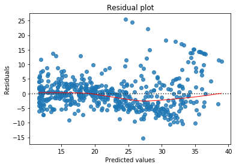

```python
sns.residplot(res2.fittedvalues, Boston['MEDV'], lowess=True, line_kws={'color':'r', 'lw':1})
plt.title('Residual plot')
plt.xlabel('Predicted values')
plt.ylabel('Residuals')
plt.show()
```

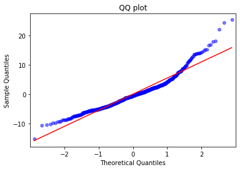

```python
ProbPlot(res2.resid).qqplot(alpha=0.5, markersize=5, line='s')
plt.title('QQ plot')
plt.show()
```

then we see that when the lstat$^2$ term is included in the model, there is little discernible pattern in the residuals.

In order to create a cubic fit, we can include a predictor in the form np.power(X, 3). However, this approach can start to get cumbersome for higher order polynomials. A better approach involves using the vander() function to transform the variables. Alternatively, you could use numpy's polyfit() function.

```python
model5 = smf.ols('MEDV ~ np.vander(Boston.LSTAT, 6)[:,:5]', data=Boston).fit()
print(model5.summary())
```

```
                            OLS Regression Results
==============================================================================
Dep. Variable:                   MEDV   R-squared:                       0.682
Model:                            OLS   Adj. R-squared:                  0.679
Method:                 Least Squares   F-statistic:                     214.2
Date:                Mon, 25 May 2020   Prob (F-statistic):          8.73e-122
Time:                        10:44:21   Log-Likelihood:                -1550.6
No. Observations:                 506   AIC:                             3113.
Df Residuals:                     500   BIC:                             3139.
Df Model:                           5
Covariance Type:            nonrobust
========================================================================================================
                                           coef    std err          t      P>|t|      [0.025      0.975]
--------------------------------------------------------------------------------------------------------
Intercept                               67.6997      3.604     18.783      0.000      60.618      74.781
np.vander(Boston.LSTAT, 6)[:, :5][0] -1.632e-05   4.42e-06     -3.692      0.000    -2.5e-05   -7.63e-06
np.vander(Boston.LSTAT, 6)[:, :5][1]     0.0017      0.000      4.143      0.000       0.001       0.003
np.vander(Boston.LSTAT, 6)[:, :5][2]    -0.0683      0.014     -4.747      0.000      -0.097      -0.040
np.vander(Boston.LSTAT, 6)[:, :5][3]     1.2728      0.223      5.703      0.000       0.834       1.711
np.vander(Boston.LSTAT, 6)[:, :5][4]   -11.9911      1.526     -7.859      0.000     -14.989      -8.994
==============================================================================
Omnibus:                      144.085   Durbin-Watson:                   0.987
Prob(Omnibus):                  0.000   Jarque-Bera (JB):              494.545
Skew:                           1.292   Prob(JB):                    4.08e-108
Kurtosis:                       7.096   Cond. No.                     1.37e+08
==============================================================================

Warnings:
[1] Standard Errors assume that the covariance matrix of the errors is correctly specified.
[2] The condition number is large, 1.37e+08. This might indicate that there are
strong multicollinearity or other numerical problems.
```

This suggests that including additional polynomial terms, up to the fifth order, leads to an improvement in the model fit! However, further investigation of the data reveals that no polynomial terms beyond the fifth order have significant p-values in a regression fit.

Of course, we are in no way restricted to using polynomial transformations of the predictors. Here we try a log transformation.

```python
model_log = smf.ols('MEDV ~ np.log(Boston.RM)', data=Boston).fit()
print(model_log.summary())
```

```
                            OLS Regression Results
==============================================================================
Dep. Variable:                   MEDV   R-squared:                       0.436
Model:                            OLS   Adj. R-squared:                  0.435
Method:                 Least Squares   F-statistic:                     389.3
Date:                Mon, 25 May 2020   Prob (F-statistic):           1.22e-64
Time:                        10:44:21   Log-Likelihood:                -1695.4
No. Observations:                 506   AIC:                             3395.
Df Residuals:                     504   BIC:                             3403.
Df Model:                           1
Covariance Type:            nonrobust
=====================================================================================
                        coef    std err          t      P>|t|      [0.025      0.975]
-------------------------------------------------------------------------------------
Intercept           -76.4878      5.028    -15.213      0.000     -86.366     -66.610
np.log(Boston.RM)    54.0546      2.739     19.732      0.000      48.672      59.437
==============================================================================
Omnibus:                      117.102   Durbin-Watson:                   0.681
Prob(Omnibus):                  0.000   Jarque-Bera (JB):              584.336
Skew:                           0.916   Prob(JB):                    1.30e-127
Kurtosis:                       7.936   Cond. No.                         38.9
==============================================================================

Warnings:
[1] Standard Errors assume that the covariance matrix of the errors is correctly specified.
```